# prasan_assignment

**Objective:** Use deep learning model to predict the (x, y) coordinate position of the single bright/white pixel (value 255) in a 50×50 grayscale image where all other pixels are 0.

**Nature of the Problem Space:** The problem space contains only 2,500 mathematically distinct samples, since each image is uniquely defined by the position of a single white pixel in a 50×50 grid, and each position corresponds to exactly one unique image. Total possible positions=50×50=2,500 images. Therefore, the dataset is finite and fully enumerable. The mapping from input to output is perfectly deterministic:

- Input: One pixel at coordinate (x, y) has value 255
- Output: The coordinate (x, y)

There is no ambiguity or stochastic behavior (no noise or variation). Each input has exactly one valid output. This creates a one-to-one mapping between image and coordinate label. We are basically trying to locate the index of the maximum pixel value (equivalent to a spatial argmax operation over the image). Thus, the model is not learning complex patterns but rather it is approximating a deterministic spatial lookup function.

**NOTE:** Because the space is fully bounded and contains only 2,500 unique inputs:

- Memorization is sufficient to solve the task.
- Generalization is trivial, since all possible configurations can be enumerated.
- Even a shallow model can achieve near-zero loss.
- A deep learning model is technically over-parameterized for this problem. Deep learning is used here primarily to demonstrate supervised regression workflows rather than because of inherent problem complexity.

This makes the task fundamentally different from real-world vision problems, where data is continuous, noisy, and highly variable. The problem becomes meaningfully complex only when variations are introduced in the data (data augmentation), at which point the model must learn robust localization rather than performing a simple lookup operation.

# Dataset Generation

- **Image Dimensions:** 50 × 50 pixels
- **Pixel Values:**
  - All pixels = 0
  - One randomly selected pixel = 255
- **Single bright pixel per image**
- **Labels:** Store the corresponding **(x, y)** coordinates of the bright pixel
- **Coordinate Convention:**
  - `x` → horizontal axis (column index, increases to the right)
  - `y` → vertical axis (row index, increases downward)
  - origin at top-left (0,0)

```python
# Install project dependencies into the active notebook environment.
# Using %pip here ensures the packages go into the SAME Python kernel

%pip install -r requirements.txt

# Import Libraries and Set Global Configuration

import numpy as np
import torch
import torch.nn as nn
from torch.utils.data import Dataset, DataLoader
from pathlib import Path
from sklearn.model_selection import train_test_split
from tqdm.auto import tqdm
import matplotlib.pyplot as plt
import time

# Set random seeds for reproducibility across all operations
RANDOM_SEED = 42
np.random.seed(RANDOM_SEED)
torch.manual_seed(RANDOM_SEED)

# Image specifications
IMAGE_HEIGHT = 50
IMAGE_WIDTH = 50
IMAGE_SHAPE = (IMAGE_HEIGHT, IMAGE_WIDTH)

# Pixel values for binary image
BACKGROUND_VALUE = 0        # All pixels except the target
TARGET_PIXEL_VALUE = 255    # The single bright pixel we want to locate

# Dataset split ratios: 80% train, 10% validation, 10% testing
VAL_SIZE = 0.1
TEST_SIZE = 0.1

# Training hyperparameters
BATCH_SIZE = 32  # Number of samples processed together
NUM_EPOCHS = 25  # Number of complete passes through training data
LEARNING_RATE = 1e-3  # Step size for weight updates

# Normalization constant
PIXEL_MAX_VALUE = 255.0

# Device configuration - using CPU for compatibility
DEVICE = torch.device('cpu')

# Directory structure
BASE_DIR = Path.cwd()
DATA_DIR = BASE_DIR / "synthetic_data"
PREPROCESSED_DIR = BASE_DIR / "preprocessed_data"

print(f"Training on: {DEVICE}")
print(f"Data split: {100*(1-VAL_SIZE-TEST_SIZE):.0f}% train, {100*VAL_SIZE:.0f}% val, {100*TEST_SIZE:.0f}% test")
```

```
Training on: cpu
Data split: 80% train, 10% val, 10% test
```

```python
# ============================================================================
# DATA GENERATION MODULE
# Generate synthetic dataset with one bright pixel per image
# ============================================================================

def generate_all_possible_samples():
    """
    Create every possible 50x50 image with one bright pixel.
    Returns 2500 images (50x50 grid positions) and their coordinates.
    Coordinates are in (x, y) format where x is column, y is row.
    """
    total_samples = IMAGE_HEIGHT * IMAGE_WIDTH

    images = np.zeros((total_samples, IMAGE_HEIGHT, IMAGE_WIDTH), dtype=np.uint8)
    coordinates = np.zeros((total_samples, 2), dtype=np.int32)

    sample_idx = 0

    # Loop through every pixel position in the 50x50 grid
    for y in range(IMAGE_HEIGHT):
        for x in range(IMAGE_WIDTH):
            # Start with blank image
            img = np.full(IMAGE_SHAPE, BACKGROUND_VALUE, dtype=np.uint8)

            # Place single bright pixel at current position
            img[y, x] = TARGET_PIXEL_VALUE

            images[sample_idx] = img
            coordinates[sample_idx] = [x, y]

            sample_idx += 1

    return images, coordinates


def split_data(images, coordinates, val_size, test_size, random_state):
    """
    Split dataset into train/validation/test sets.
    First split: separate test set
    Second split: divide remaining into train and validation
    This ensures proper 80/10/10 distribution.
    """
    # First split: 90% train+val, 10% test
    X_temp, X_test, y_temp, y_test = train_test_split(
        images, coordinates,
        test_size=test_size,
        random_state=random_state,
        shuffle=True
    )

    # Second split: from remaining 90%, take 1/9 for validation (10% of total)
    val_size_adjusted = val_size / (1 - test_size)
    X_train, X_val, y_train, y_val = train_test_split(
        X_temp, y_temp,
        test_size=val_size_adjusted,
        random_state=random_state,
        shuffle=True
    )

    splits = {
        'train': {'images': X_train, 'coordinates': y_train},
        'val': {'images': X_val, 'coordinates': y_val},
        'test': {'images': X_test, 'coordinates': y_test}
    }

    return splits


def save_data_to_disk(splits, data_dir):
    """
    Save each split as compressed numpy file for later loading.
    Using .npz format keeps file sizes small.
    """
    for split_name, split_content in splits.items():
        filepath = data_dir / f"{split_name}_data.npz"

        np.savez_compressed(
            filepath,
            images=split_content['images'],
            coordinates=split_content['coordinates']
        )

        print(f"Saved {split_name} split: {filepath}")
        print(f"  Images: {split_content['images'].shape}")
        print(f"  Coordinates: {split_content['coordinates'].shape}")


# Execute data generation
print("="*70)
print("DATA GENERATION")
print("="*70)
images, coordinates = generate_all_possible_samples()
print(f"Generated {len(images)} total samples")

print("\nSplitting into train/val/test...")
splits = split_data(images, coordinates, VAL_SIZE, TEST_SIZE, RANDOM_SEED)

print("\nSaving to disk...")
save_data_to_disk(splits, DATA_DIR)
```

```
======================================================================
DATA GENERATION
======================================================================
Generated 2500 total samples

Splitting into train/val/test...

Saving to disk...
Saved train split: c:\Users\nh1pr\Documents\DeepEdgeAI\synthetic_data\train_data.npz
  Images: (1999, 50, 50)
  Coordinates: (1999, 2)
Saved val split: c:\Users\nh1pr\Documents\DeepEdgeAI\synthetic_data\val_data.npz
  Images: (251, 50, 50)
  Coordinates: (251, 2)
Saved test split: c:\Users\nh1pr\Documents\DeepEdgeAI\synthetic_data\test_data.npz
  Images: (250, 50, 50)
  Coordinates: (250, 2)
```

```
----------------------------------------------------------------------
VISUALIZATION 1: Random Sample Grid
----------------------------------------------------------------------
```

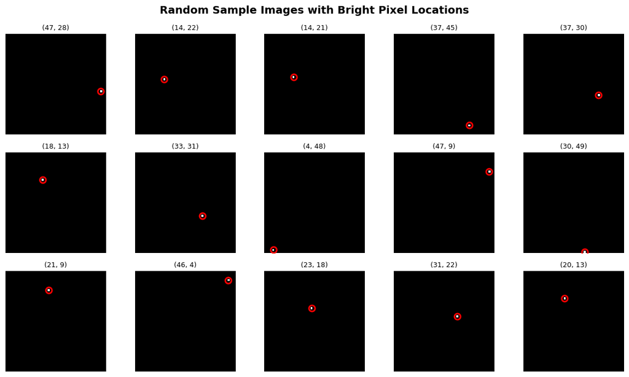

```
Displayed 15 random samples with red circles marking bright pixel locations

----------------------------------------------------------------------
VISUALIZATION 2: Coordinate Distribution by Split
----------------------------------------------------------------------
```

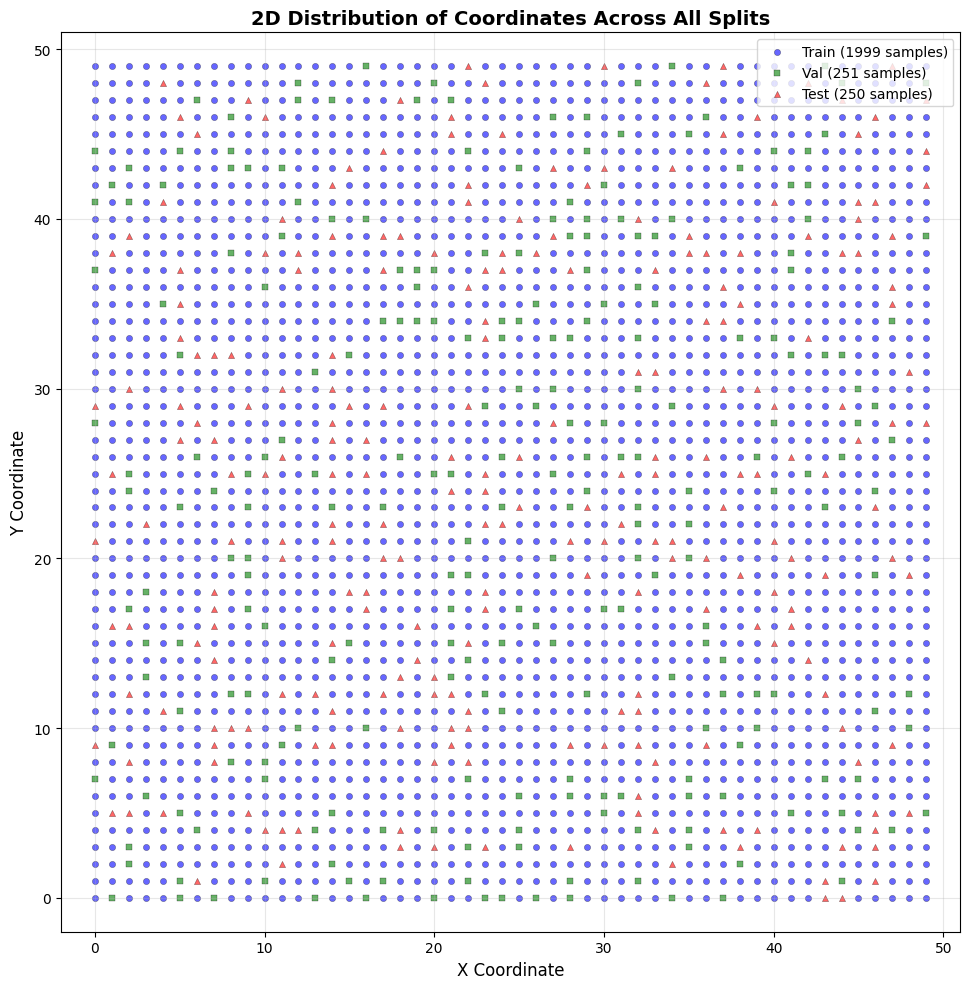

```
Coordinate distribution shows random assignment across the 50x50 grid
Blue = Train | Green = Validation | Red = Test

----------------------------------------------------------------------
VISUALIZATION 3: Sequential Sample Generation
----------------------------------------------------------------------
```

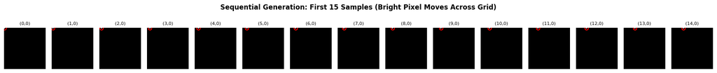

```
Displayed first 15 samples showing systematic pixel movement
```

```python
# Data Generation Visualization

# ============================================================================
# VISUALIZATION 1: RANDOM SAMPLE GRID
# ============================================================================
print("\n" + "-"*70)
print("VISUALIZATION 1: Random Sample Grid")
print("-"*70)

num_samples_to_show = 15
random_indices = np.random.choice(len(images), num_samples_to_show, replace=False)

fig, axes = plt.subplots(3, 5, figsize=(12, 7))
axes = axes.flatten()

for i, idx in enumerate(random_indices):
    img = images[idx]
    x, y = coordinates[idx]

    axes[i].imshow(img, cmap='gray', vmin=0, vmax=255)
    axes[i].plot(x, y, 'ro', markersize=8, markeredgewidth=2, markerfacecolor='none')
    axes[i].set_title(f'({x}, {y})', fontsize=9)
    axes[i].axis('off')

plt.suptitle('Random Sample Images with Bright Pixel Locations', fontsize=14, fontweight='bold')
plt.tight_layout()
plt.show()

print("Displayed 15 random samples with red circles marking bright pixel locations")

# ============================================================================
# VISUALIZATION 2: COORDINATE DISTRIBUTION (ALL SPLITS)
# ============================================================================
print("\n" + "-"*70)
print("VISUALIZATION 2: Coordinate Distribution by Split")
print("-"*70)

fig, ax = plt.subplots(1, 1, figsize=(10, 10))

# Plot each split with different colors
colors = {'train': 'blue', 'val': 'green', 'test': 'red'}
markers = {'train': 'o', 'val': 's', 'test': '^'}

for split_name in ['train', 'val', 'test']:
    coords = splits[split_name]['coordinates']
    ax.scatter(coords[:, 0], coords[:, 1],
              c=colors[split_name],
              marker=markers[split_name],
              s=20,
              alpha=0.6,
              label=f'{split_name.capitalize()} ({len(coords)} samples)',
              edgecolors='black',
              linewidth=0.3)

ax.set_xlabel('X Coordinate', fontsize=12)
ax.set_ylabel('Y Coordinate', fontsize=12)
ax.set_title('2D Distribution of Coordinates Across All Splits', fontsize=14, fontweight='bold')
ax.legend(fontsize=10, loc='upper right')
ax.grid(True, alpha=0.3)
ax.set_xlim(-2, 51)
ax.set_ylim(-2, 51)
ax.set_aspect('equal')

plt.tight_layout()
plt.show()

print("Coordinate distribution shows random assignment across the 50x50 grid")
print("Blue = Train | Green = Validation | Red = Test")

# ============================================================================
# VISUALIZATION 3: SEQUENTIAL SAMPLES
# ============================================================================
print("\n" + "-"*70)
print("VISUALIZATION 3: Sequential Sample Generation")
print("-"*70)

# Show first 15 samples to demonstrate systematic generation
num_sequential = 15

fig, axes = plt.subplots(1, num_sequential, figsize=(18, 2))

for i in range(num_sequential):
    img = images[i]
    x, y = coordinates[i]

    axes[i].imshow(img, cmap='gray', vmin=0, vmax=255)
    axes[i].plot(x, y, 'ro', markersize=6, markeredgewidth=1.5, markerfacecolor='none')
    axes[i].set_title(f'({x},{y})', fontsize=8)
    axes[i].axis('off')

plt.suptitle('Sequential Generation: First 15 Samples (Bright Pixel Moves Across Grid)',
             fontsize=12, fontweight='bold')
plt.tight_layout()
plt.show()

print(f"Displayed first {num_sequential} samples showing systematic pixel movement")
```

# Data Preprocessing

Neural networks train more efficiently when inputs are scaled to a smaller range such as: 0 to 1. Reasons for normalization:

- Improves gradient stability
- Prevents large weight updates
- Accelerates convergence
- Reduces numerical instability

Even though the data here is simple, normalization ensures consistent training dynamics and follows best practices in deep learning.

```python
# ============================================================================
# DATA PREPROCESSING MODULE
# Normalize pixel values and coordinates to [0,1] range for better training
# ============================================================================

def normalize_images(images):
    """
    Scale pixel values from [0, 255] to [0, 1].
    Neural networks perform better with smaller input values.
    """
    normalized = images.astype(np.float32) / PIXEL_MAX_VALUE
    return normalized


def normalize_coordinates(coordinates, image_shape):
    """
    Scale coordinates to [0, 1] based on image dimensions.
    For 50x50 image: coordinates range [0, 49], so divide by 49.
    This keeps target values in same range as inputs.
    """
    coords_float = coordinates.astype(np.float32)

    height, width = image_shape
    max_x = width - 1
    max_y = height - 1

    coords_float[:, 0] = coords_float[:, 0] / max_x
    coords_float[:, 1] = coords_float[:, 1] / max_y

    return coords_float


def denormalize_coordinates(normalized_coords, image_shape=(50, 50)):
    """
    Convert normalized coordinates back to pixel values.
    Multiply by (dimension - 1) and round to nearest integer. Used for visualization and evaluation.
    """
    coords = normalized_coords.copy()
    height, width = image_shape

    coords[:, 0] = coords[:, 0] * (width - 1)
    coords[:, 1] = coords[:, 1] * (height - 1)

    coords = np.round(coords).astype(np.int32)
    coords[:, 0] = np.clip(coords[:, 0], 0, width - 1)
    coords[:, 1] = np.clip(coords[:, 1], 0, height - 1)

    return coords


def load_raw_data(split_name, data_dir):
    """Load raw data from disk."""
    filepath = data_dir / f"{split_name}_data.npz"

    if not filepath.exists():
        raise FileNotFoundError(f"Data file not found: {filepath}")

    data = np.load(filepath)
    return {'images': data['images'], 'coordinates': data['coordinates']}


def preprocess_and_save(split_name, data_dir, output_dir):
    """
    Load, normalize, and save preprocessed data.
    Normalization uses image dimensions to ensure train/val/test are scaled identically.
    """
    raw_data = load_raw_data(split_name, data_dir)
    image_shape = raw_data['images'].shape[1:]

    normalized_images = normalize_images(raw_data['images'])
    normalized_coords = normalize_coordinates(raw_data['coordinates'], image_shape)

    preprocessed = {
        'images': normalized_images,
        'coordinates': normalized_coords
    }

    output_path = output_dir / f"{split_name}_preprocessed.npz"
    np.savez_compressed(
        output_path,
        images=preprocessed['images'],
        coordinates=preprocessed['coordinates']
    )

    print(f"{split_name}: {len(normalized_images)} samples - "
          f"Image range [{normalized_images.min():.3f}, {normalized_images.max():.3f}] - "
          f"Coord range [{normalized_coords.min():.3f}, {normalized_coords.max():.3f}]")

    return preprocessed


# Execute preprocessing
print("="*70)
print("DATA PREPROCESSING")
print("="*70)
print("\nNormalizing all splits to [0,1] range...")
train_preprocessed = preprocess_and_save('train', DATA_DIR, PREPROCESSED_DIR)
val_preprocessed = preprocess_and_save('val', DATA_DIR, PREPROCESSED_DIR)
test_preprocessed = preprocess_and_save('test', DATA_DIR, PREPROCESSED_DIR)
```

```
======================================================================
DATA PREPROCESSING
======================================================================

Normalizing all splits to [0,1] range...
train: 1999 samples - Image range [0.000, 1.000] - Coord range [0.000, 1.000]
val: 251 samples - Image range [0.000, 1.000] - Coord range [0.000, 1.000]
test: 250 samples - Image range [0.000, 1.000] - Coord range [0.000, 1.000]
```

```python
# ============================================================================
# PyTorch Dataset Class
# Custom dataset class to handle data loading for PyTorch
# ============================================================================

class PixelLocatorDataset(Dataset):
    """
    PyTorch Dataset for pixel localization task.

    Handles shape transformation:
    - Input images: (50, 50) -> (1, 50, 50) for CNN
    - Coordinates: (2,) remain as is
    """

    def __init__(self, images, coordinates):
        self.images = images
        self.coordinates = coordinates

    def __len__(self):
        return len(self.images)

    def __getitem__(self, idx):
        """
        Get single sample and convert to tensors.
        Add channel dimension for CNN: (50, 50) -> (1, 50, 50)
        """
        img = self.images[idx]
        coords = self.coordinates[idx]

        img_tensor = torch.from_numpy(img).float()
        coords_tensor = torch.from_numpy(coords).float()

        # Add channel dimension for grayscale image
        img_tensor = img_tensor.unsqueeze(0)

        return img_tensor, coords_tensor


def load_preprocessed_data(split_name, preprocessed_dir):
    """Load normalized data from disk."""
    filepath = preprocessed_dir / f"{split_name}_preprocessed.npz"

    if not filepath.exists():
        raise FileNotFoundError(f"File not found: {filepath}")

    data = np.load(filepath)
    return {'images': data['images'], 'coordinates': data['coordinates']}


def create_dataloaders(batch_size=32):
    """
    Create DataLoaders for all splits.

    DataLoader benefits:
    - Automatic batching
    - Shuffling for train set (improves generalization)
    - No shuffling for val/test (consistent evaluation)
    """
    # Load all splits
    train_data = load_preprocessed_data('train', PREPROCESSED_DIR)
    val_data = load_preprocessed_data('val', PREPROCESSED_DIR)
    test_data = load_preprocessed_data('test', PREPROCESSED_DIR)

    # Create datasets
    train_dataset = PixelLocatorDataset(
        train_data['images'],
        train_data['coordinates']
    )
    val_dataset = PixelLocatorDataset(
        val_data['images'],
        val_data['coordinates']
    )
    test_dataset = PixelLocatorDataset(
        test_data['images'],
        test_data['coordinates']
    )

    # Create DataLoaders
    train_loader = DataLoader(
        train_dataset,
        batch_size=batch_size,
        shuffle=True,
        num_workers=0
    )
    val_loader = DataLoader(
        val_dataset,
        batch_size=batch_size,
        shuffle=False,
        num_workers=0
    )
    test_loader = DataLoader(
        test_dataset,
        batch_size=batch_size,
        shuffle=False,
        num_workers=0
    )

    return {
        'train_loader': train_loader,
        'val_loader': val_loader,
        'test_loader': test_loader,
        'train_dataset': train_dataset,  # Return datasets too
        'val_dataset': val_dataset,
        'test_dataset': test_dataset
    }


# Create DataLoaders
print("="*70)
print("CREATING DATALOADERS")
print("="*70)
dataloaders = create_dataloaders(batch_size=BATCH_SIZE)

# Extract datasets for easy access
train_dataset = dataloaders['train_dataset']
val_dataset = dataloaders['val_dataset']
test_dataset = dataloaders['test_dataset']

print(f"Train batches: {len(dataloaders['train_loader'])}")
print(f"Validation batches: {len(dataloaders['val_loader'])}")
print(f"Test batches: {len(dataloaders['test_loader'])}")
print("\n")
```

```
======================================================================
CREATING DATALOADERS
======================================================================
Train batches: 63
Validation batches: 8
Test batches: 8
```

```
======================================================================
DATASET SHAPE VERIFICATION
======================================================================

1. SINGLE SAMPLE SHAPES:
   Original image shape: (50, 50)
   Transformed image tensor shape:   (1, 50, 50)
   Coordinate tensor shape:          (2,)

2. BATCH SHAPES:
   Image batch shape:      (32, 1, 50, 50)
   Coordinate batch shape: (32, 2)

   Format: (batch_size, channels, height, width)
   - Batch size: 32
   - Channels: 1 (grayscale)
   - Height: 50 pixels
   - Width: 50 pixels

======================================================================
SAMPLE BATCH VISUALIZATION
======================================================================
```

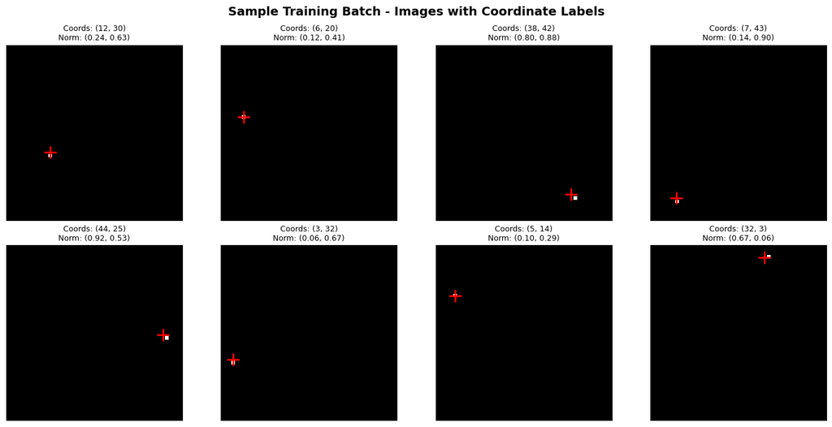

```
Displayed 8 random samples from a training batch
Red '+' marks the location of the bright pixel (value = 1.0)
Title shows both pixel coordinates and normalized coordinates
```

```python
# Dataset Inspection and Verification
# Verify data shapes and visualize sample batches

print("="*70)
print("DATASET SHAPE VERIFICATION")
print("="*70)

# Get a single sample to inspect shapes
sample_img, sample_coord = train_dataset[0]

print("\n1. SINGLE SAMPLE SHAPES:")
print(f"   Original image shape: (50, 50)")
print(f"   Transformed image tensor shape:   {tuple(sample_img.shape)}")
print(f"   Coordinate tensor shape:          {tuple(sample_coord.shape)}")

# Get a batch to inspect batch shapes
train_iter = iter(dataloaders['train_loader'])
batch_images, batch_coords = next(train_iter)

print("\n2. BATCH SHAPES:")
print(f"   Image batch shape:      {tuple(batch_images.shape)}")
print(f"   Coordinate batch shape: {tuple(batch_coords.shape)}")

print("\n   Format: (batch_size, channels, height, width)")
print(f"   - Batch size: {batch_images.shape[0]}")
print(f"   - Channels: {batch_images.shape[1]} (grayscale)")
print(f"   - Height: {batch_images.shape[2]} pixels")
print(f"   - Width: {batch_images.shape[3]} pixels")

print("\n" + "="*70)
print("SAMPLE BATCH VISUALIZATION")
print("="*70)

# Get a batch from training loader for visualization
train_iter = iter(dataloaders['train_loader'])
vis_images, vis_coords = next(train_iter)

# Select random samples from the batch
num_samples = 8
batch_size = vis_images.shape[0]
sample_indices = np.random.choice(batch_size, min(num_samples, batch_size), replace=False)

# Create visualization
fig, axes = plt.subplots(2, 4, figsize=(14, 7))
axes = axes.flatten()

for i, idx in enumerate(sample_indices):
    # Extract image and coordinates
    img = vis_images[idx, 0].numpy()  # Remove channel dimension for display
    coords = vis_coords[idx].numpy()

    # Denormalize coordinates for display
    x_pixel = int(coords[0] * 49)
    y_pixel = int(coords[1] * 49)

    # Display image
    axes[i].imshow(img, cmap='gray', vmin=0, vmax=1)

    # Mark the bright pixel location
    axes[i].plot(x_pixel, y_pixel, 'r+', markersize=15, markeredgewidth=2)

    # Add title with coordinates
    axes[i].set_title(f'Coords: ({x_pixel}, {y_pixel})\nNorm: ({coords[0]:.2f}, {coords[1]:.2f})',
                      fontsize=9)
    axes[i].axis('off')

plt.suptitle('Sample Training Batch - Images with Coordinate Labels',
             fontsize=14, fontweight='bold', y=0.98)
plt.tight_layout()
plt.show()

print(f"\nDisplayed {len(sample_indices)} random samples from a training batch")
print("Red '+' marks the location of the bright pixel (value = 1.0)")
print("Title shows both pixel coordinates and normalized coordinates")
print("\n")
```

# Model Architecture

CNNs are particularly well-suited for image data because:

- They preserve spatial structure
- They use parameter sharing, reducing total parameters
- They are translation-aware (feature detection independent of position) In this problem, the location of the white pixel is spatial information. A CNN can learn filters that activate when a high-intensity pixel appears in a region of the image, making it a natural architectural choice for image-based regression.

The architecture is intentionally kept shallow because:

- The task is simple (only one active pixel).
- The input resolution is small (50×50).
- The mapping from input to output is deterministic and low complexity.

Therefore, a small number of convolutional layers followed by fully connected layers is sufficient to:

- Extract spatial features
- Map those features to continuous coordinate outputs (x, y)

The final layer uses a linear activation because this is a regression problem predicting continuous values.

```python
# ============================================================================
# CNN MODEL ARCHITECTURE
# Build convolutional neural network for pixel localization
# ============================================================================

class PixelLocatorCNN(nn.Module):
    """
    CNN architecture for predicting pixel coordinates.

    Design rationale:
    - 3 conv layers progressively extract spatial features
    - Each conv layer uses 3x3 kernels (standard for feature extraction)
    - MaxPool reduces spatial dimensions while keeping important features
    - Final layers compress to 2 outputs: x and y coordinates

    Architecture flow:
    Input (1, 50, 50) -> Conv+Pool -> (16, 25, 25) ->
    Conv+Pool -> (32, 12, 12) -> Conv+Pool -> (64, 6, 6) ->
    Flatten -> FC(128) -> Output(2)
    """

    def __init__(self):
        super(PixelLocatorCNN, self).__init__()

        # First conv block: extract basic features
        # padding=1 keeps spatial dimensions same before pooling
        self.conv1 = nn.Conv2d(
            in_channels=1,
            out_channels=16,
            kernel_size=3,
            padding=1
        )
        self.pool1 = nn.MaxPool2d(kernel_size=2, stride=2)

        # Second conv block: combine basic features into patterns
        self.conv2 = nn.Conv2d(
            in_channels=16,
            out_channels=32,
            kernel_size=3,
            padding=1
        )
        self.pool2 = nn.MaxPool2d(kernel_size=2, stride=2)

        # Third conv block: high-level feature extraction
        self.conv3 = nn.Conv2d(
            in_channels=32,
            out_channels=64,
            kernel_size=3,
            padding=1
        )
        self.pool3 = nn.MaxPool2d(kernel_size=2, stride=2)

        # Flattened size after all pooling: 64 channels * 6 * 6
        self.flatten_size = 64 * 6 * 6

        # Dense layer to learn coordinate relationships
        self.fc1 = nn.Linear(self.flatten_size, 128)

        # Output layer: 2 neurons for (x, y) with no activation
        # Linear activation is appropriate for regression
        self.fc_output = nn.Linear(128, 2)

        # ReLU adds non-linearity for better feature learning
        self.relu = nn.ReLU()


    def forward(self, x):
        """
        Forward pass through network.
        Each conv block: convolution -> activation -> pooling
        Then flatten and pass through dense layers.
        """
        x = x.to(torch.float32)

        # Conv block 1
        x = self.conv1(x)
        x = self.relu(x)
        x = self.pool1(x)

        # Conv block 2
        x = self.conv2(x)
        x = self.relu(x)
        x = self.pool2(x)

        # Conv block 3
        x = self.conv3(x)
        x = self.relu(x)
        x = self.pool3(x)

        # Flatten for dense layers
        x = x.reshape(-1, self.flatten_size)

        # Dense layer with activation
        x = self.fc1(x)
        x = self.relu(x)

        # Output layer (no activation for regression)
        x = self.fc_output(x)

        return x


def create_cnn_model():
    """
    Initialize model with loss function and optimizer.

    Loss: MSE is standard for regression tasks
    Optimizer: Adam adapts learning rate automatically
    """
    model = PixelLocatorCNN()
    criterion = nn.MSELoss()
    optimizer = torch.optim.Adam(model.parameters(), lr=LEARNING_RATE)

    return model, optimizer, criterion


# Display model architecture
print("="*70)
print("CNN MODEL ARCHITECTURE")
print("="*70)
model = PixelLocatorCNN()
print(model)
print("="*70)

total_params = sum(p.numel() for p in model.parameters())
trainable_params = sum(p.numel() for p in model.parameters() if p.requires_grad)
print(f"\nTotal Parameters: {total_params:,}")
print(f"Trainable Parameters: {trainable_params:,}")

# Test forward pass
dummy_input = torch.randn(1, 1, 50, 50)
with torch.no_grad():
    output = model(dummy_input)
print(f"\nTest - Input: {dummy_input.shape} -> Output: {output.shape}")
print("\n")
```

```
======================================================================
CNN MODEL ARCHITECTURE
======================================================================
PixelLocatorCNN(
  (conv1): Conv2d(1, 16, kernel_size=(3, 3), stride=(1, 1), padding=(1, 1))
  (pool1): MaxPool2d(kernel_size=2, stride=2, padding=0, dilation=1, ceil_mode=False)
  (conv2): Conv2d(16, 32, kernel_size=(3, 3), stride=(1, 1), padding=(1, 1))
  (pool2): MaxPool2d(kernel_size=2, stride=2, padding=0, dilation=1, ceil_mode=False)
  (conv3): Conv2d(32, 64, kernel_size=(3, 3), stride=(1, 1), padding=(1, 1))
  (pool3): MaxPool2d(kernel_size=2, stride=2, padding=0, dilation=1, ceil_mode=False)
  (fc1): Linear(in_features=2304, out_features=128, bias=True)
  (fc_output): Linear(in_features=128, out_features=2, bias=True)
  (relu): ReLU()
)
======================================================================

Total Parameters: 318,594
Trainable Parameters: 318,594

Test - Input: torch.Size([1, 1, 50, 50]) -> Output: torch.Size([1, 2])
```

```python
# Detailed Model Architecture Analysis

print("="*80)
print("DETAILED MODEL ARCHITECTURE ANALYSIS")
print("="*80)

# Create a fresh model instance for analysis
model = PixelLocatorCNN()

print("\n" + "="*80)
print("LAYER-BY-LAYER BREAKDOWN")
print("="*80)

# Track shapes through the network
dummy_input = torch.randn(1, 1, 50, 50)
x = dummy_input

print(f"\n{'Layer':<20} {'Type':<15} {'Output Shape':<20} {'Parameters':<15}")
print("-"*80)

# Input layer
print(f"{'Input':<20} {'Input':<15} {str(tuple(x.shape)):<20} {0:<15,}")

# Conv1 + ReLU + Pool1
x = model.conv1(x)
conv1_params = sum(p.numel() for p in model.conv1.parameters())
print(f"{'conv1':<20} {'Conv2d':<15} {str(tuple(x.shape)):<20} {conv1_params:<15,}")

x = model.relu(x)
print(f"{'relu1':<20} {'ReLU':<15} {str(tuple(x.shape)):<20} {0:<15,}")

x = model.pool1(x)
print(f"{'pool1':<20} {'MaxPool2d':<15} {str(tuple(x.shape)):<20} {0:<15,}")

# Conv2 + ReLU + Pool2
x = model.conv2(x)
conv2_params = sum(p.numel() for p in model.conv2.parameters())
print(f"{'conv2':<20} {'Conv2d':<15} {str(tuple(x.shape)):<20} {conv2_params:<15,}")

x = model.relu(x)
print(f"{'relu2':<20} {'ReLU':<15} {str(tuple(x.shape)):<20} {0:<15,}")

x = model.pool2(x)
print(f"{'pool2':<20} {'MaxPool2d':<15} {str(tuple(x.shape)):<20} {0:<15,}")

# Conv3 + ReLU + Pool3
x = model.conv3(x)
conv3_params = sum(p.numel() for p in model.conv3.parameters())
print(f"{'conv3':<20} {'Conv2d':<15} {str(tuple(x.shape)):<20} {conv3_params:<15,}")

x = model.relu(x)
print(f"{'relu3':<20} {'ReLU':<15} {str(tuple(x.shape)):<20} {0:<15,}")

x = model.pool3(x)
print(f"{'pool3':<20} {'MaxPool2d':<15} {str(tuple(x.shape)):<20} {0:<15,}")

# Flatten
x = x.reshape(-1, model.flatten_size)
print(f"{'flatten':<20} {'Reshape':<15} {str(tuple(x.shape)):<20} {0:<15,}")

# FC1 + ReLU
x = model.fc1(x)
fc1_params = sum(p.numel() for p in model.fc1.parameters())
print(f"{'fc1':<20} {'Linear':<15} {str(tuple(x.shape)):<20} {fc1_params:<15,}")

x = model.relu(x)
print(f"{'relu4':<20} {'ReLU':<15} {str(tuple(x.shape)):<20} {0:<15,}")

# Output
x = model.fc_output(x)
fc_output_params = sum(p.numel() for p in model.fc_output.parameters())
print(f"{'fc_output':<20} {'Linear':<15} {str(tuple(x.shape)):<20} {fc_output_params:<15,}")

print("-"*80)

# Parameter Statistics
print("\n" + "="*80)
print("PARAMETER STATISTICS")
print("="*80)

# Parameters by layer type
conv_params = conv1_params + conv2_params + conv3_params
linear_params = fc1_params + fc_output_params

print(f"\n{'Layer Type':<20} {'Parameters':<15} {'Percentage':<15}")
print("-"*50)
print(f"{'Convolutional':<20} {conv_params:<15,} {(conv_params/total_params*100):>13.2f}%")
print(f"{'Linear (Dense)':<20} {linear_params:<15,} {(linear_params/total_params*100):>13.2f}%")
print("-"*50)
```

```
================================================================================
DETAILED MODEL ARCHITECTURE ANALYSIS
================================================================================

================================================================================
LAYER-BY-LAYER BREAKDOWN
================================================================================

Layer                Type            Output Shape         Parameters
--------------------------------------------------------------------------------
Input                Input           (1, 1, 50, 50)       0
conv1                Conv2d          (1, 16, 50, 50)      160
relu1                ReLU            (1, 16, 50, 50)      0
pool1                MaxPool2d       (1, 16, 25, 25)      0
conv2                Conv2d          (1, 32, 25, 25)      4,640
relu2                ReLU            (1, 32, 25, 25)      0
pool2                MaxPool2d       (1, 32, 12, 12)      0
conv3                Conv2d          (1, 64, 12, 12)      18,496
relu3                ReLU            (1, 64, 12, 12)      0
pool3                MaxPool2d       (1, 64, 6, 6)        0
flatten              Reshape         (1, 2304)            0
fc1                  Linear          (1, 128)             295,040
relu4                ReLU            (1, 128)             0
fc_output            Linear          (1, 2)               258
--------------------------------------------------------------------------------

================================================================================
PARAMETER STATISTICS
================================================================================

Layer Type           Parameters      Percentage
--------------------------------------------------
Convolutional        23,296                   7.31%
Linear (Dense)       295,298                 92.69%
--------------------------------------------------
```

**Note on Baseline Models and Experimental Practice**

In a typical machine learning workflow, it is good practice to begin with a simple baseline model before introducing more specialized architectures.

For this type of problem, a Multi-Layer Perceptron (MLP) could serve as a baseline because:

- The 50×50 image can be flattened into a 2500-dimensional input vector.
- The relationship between the single active pixel and its coordinates is straightforward.
- No complex spatial hierarchy is required for solving the task.

Including an MLP baseline would allow us to:

- Compare its performance against a CNN.
- Follow a structured experimentation pipeline (baseline → specialized model → comparison).

(NOTE: I have not done it here in this notebook)

```python
# ============================================================================
# CNN TRAINING MODULE with tqdm Progress Bars
# Define training and validation loops
# ============================================================================

def train_epoch(model, train_loader, criterion, optimizer, device):
    """
    Train model for one epoch.

    Steps per batch:
    1. Forward pass: compute predictions
    2. Calculate loss
    3. Backward pass: compute gradients
    4. Update weights
    """
    model.train()
    total_loss = 0.0
    num_batches = 0

    # Progress bar for batches
    pbar = tqdm(train_loader, desc="Training", leave=False)

    for images, coordinates in pbar:
        images = images.to(device)
        coordinates = coordinates.to(device)

        # Reset gradients from previous batch
        optimizer.zero_grad()

        # Forward pass
        predictions = model(images)
        loss = criterion(predictions, coordinates)

        # Backward pass and weight update
        loss.backward()
        optimizer.step()

        total_loss += loss.item()
        num_batches += 1

        # Update progress bar with current batch loss
        pbar.set_postfix({'batch_loss': f'{loss.item():.6f}'})

    return total_loss / num_batches


def validate_epoch(model, val_loader, criterion, device):
    """
    Evaluate model on validation set.
    No gradient computation needed for evaluation.
    """
    model.eval()
    total_loss = 0.0
    num_batches = 0

    # Progress bar for validation batches
    pbar = tqdm(val_loader, desc="Validating", leave=False)

    with torch.no_grad():
        for images, coordinates in pbar:
            images = images.to(device)
            coordinates = coordinates.to(device)

            predictions = model(images)
            loss = criterion(predictions, coordinates)

            total_loss += loss.item()
            num_batches += 1

            pbar.set_postfix({'batch_loss': f'{loss.item():.6f}'})

    return total_loss / num_batches


def train_model(model, train_loader, val_loader, criterion, optimizer, num_epochs, device):
    """
    Complete training loop with validation.
    """
    history = {
        'train_loss': [],
        'val_loss': [],
        'epoch_times': []
    }

    total_start_time = time.time()

    # Main epoch progress bar
    epoch_pbar = tqdm(range(num_epochs), desc="Overall Progress")

    for epoch in epoch_pbar:
        epoch_start = time.time()

        # Train and validate
        train_loss = train_epoch(model, train_loader, criterion, optimizer, device)
        val_loss = validate_epoch(model, val_loader, criterion, device)

        epoch_time = time.time() - epoch_start

        # Record history
        history['train_loss'].append(train_loss)
        history['val_loss'].append(val_loss)
        history['epoch_times'].append(epoch_time)

        # Update main progress bar
        epoch_pbar.set_postfix({
            'train_loss': f'{train_loss:.6f}',
            'val_loss': f'{val_loss:.6f}'
        })

        # Print epoch summary
        print(f"Epoch {epoch+1}/{num_epochs} - "
              f"Train: {train_loss:.6f} - "
              f"Val: {val_loss:.6f} - "
              f"Time: {epoch_time:.2f}s")

    total_training_time = time.time() - total_start_time

    # Print comprehensive training summary
    print()
    print("="*70)
    print("TRAINING COMPLETED - SUMMARY")
    print("="*70)

    # Basic metrics
    print(f"\n{'Metric':<30} {'Value':>15}")
    print("-"*70)
    print(f"{'Total Training Time':<30} {total_training_time:>12.2f}s")
    print(f"{'Average Epoch Time':<30} {np.mean(history['epoch_times']):>12.2f}s")
    print(f"{'Total Epochs':<30} {num_epochs:>15d}")

    # Loss metrics
    print(f"\n{'Loss Metrics':<30} {'Train':>15} {'Validation':>15}")
    print("-"*70)
    print(f"{'Initial Loss':<30} {history['train_loss'][0]:>15.6f} {history['val_loss'][0]:>15.6f}")
    print(f"{'Final Loss':<30} {history['train_loss'][-1]:>15.6f} {history['val_loss'][-1]:>15.6f}")

    return history
```

```python
# Initialize and train the CNN model

print("="*70)
print("MODEL TRAINING")
print("="*70)
print()

# Initialize model
cnn_model, cnn_optimizer, cnn_criterion = create_cnn_model()
cnn_model = cnn_model.to(DEVICE)

# Train the model
cnn_history = train_model(
    model=cnn_model,
    train_loader=dataloaders['train_loader'],
    val_loader=dataloaders['val_loader'],
    criterion=cnn_criterion,
    optimizer=cnn_optimizer,
    num_epochs=NUM_EPOCHS,
    device=DEVICE
)
```

```
======================================================================
MODEL TRAINING
======================================================================
```

```
======================================================================
TRAINING COMPLETED - SUMMARY
======================================================================

Metric                                   Value
----------------------------------------------------------------------
Total Training Time                  134.44s
Average Epoch Time                     5.38s
Total Epochs                                25

Loss Metrics                             Train      Validation
----------------------------------------------------------------------
Initial Loss                          0.092470        0.028555
Final Loss                            0.000042        0.000059
```

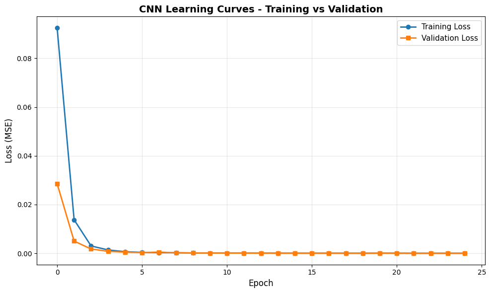

```python
# Plot Learning Curves
# Visualize training and validation loss over epochs

plt.figure(figsize=(10, 6))
plt.plot(cnn_history['train_loss'], label='Training Loss', linewidth=2, marker='o')
plt.plot(cnn_history['val_loss'], label='Validation Loss', linewidth=2, marker='s')
plt.xlabel('Epoch', fontsize=12)
plt.ylabel('Loss (MSE)', fontsize=12)
plt.title('CNN Learning Curves - Training vs Validation', fontsize=14, fontweight='bold')
plt.legend(fontsize=11)
plt.grid(True, alpha=0.3)
plt.tight_layout()
plt.show()
```

```
======================================================================
TEST SET EVALUATION
======================================================================

--- BASIC METRICS ---
Mean Euclidean Pixel Error:   0.255598
Median Euclidean Pixel Error: 0.000000
Std Dev Pixel Error:          0.454609
Min Euclidean Pixel Error:    0.000000
Max Euclidean Pixel Error:    1.414214
Range of Pixel Error:         1.414214

Test Loss (MSE): 0.000053
Root Mean Squared Error (RMSE): 0.007249
======================================================================


Generating 2D scatter plot...
```

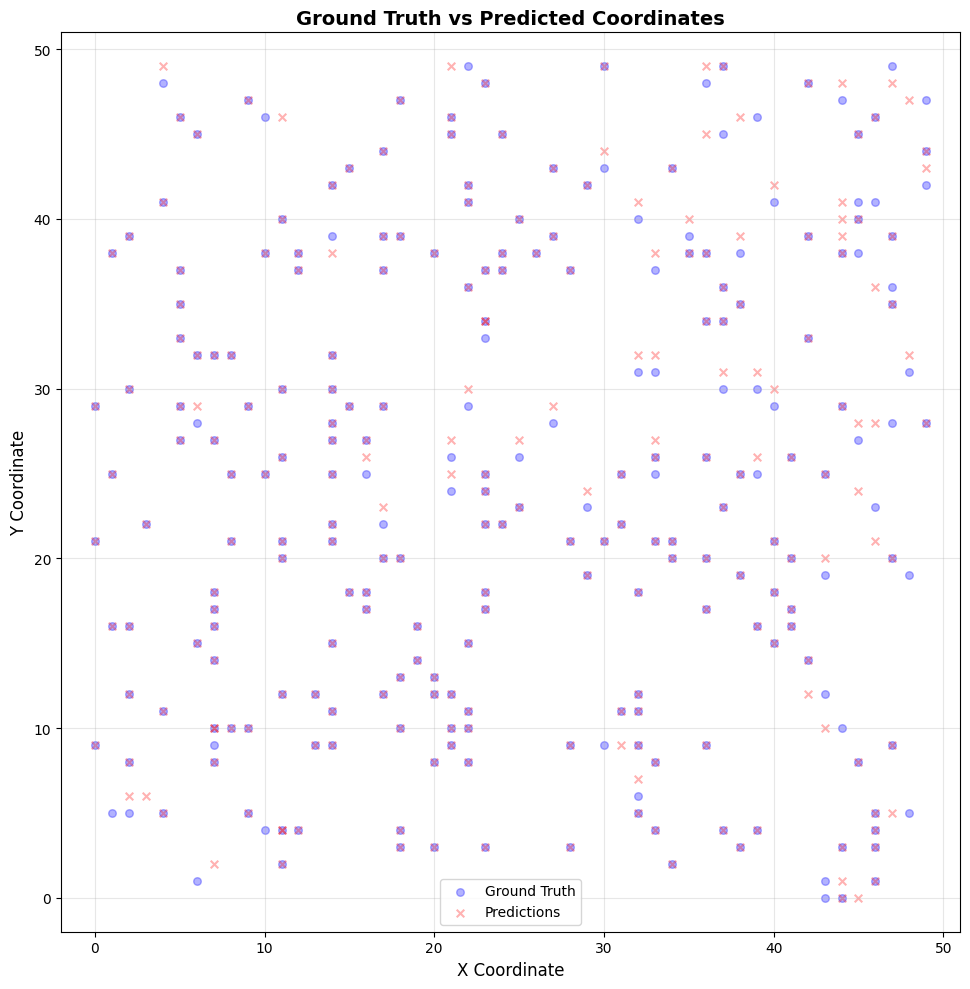

```python
# Test Set Evaluation
# Evaluate final model performance on unseen test data

def test_model(model, test_loader, criterion, device):
    """
    Evaluate model on test set and collect predictions for analysis.
    Returns average loss and all predictions with ground truth.
    """
    model.eval()
    total_loss = 0.0
    num_batches = 0

    all_predictions = []
    all_ground_truth = []
    all_images = []

    with torch.no_grad():
        for images, coordinates in test_loader:
            images = images.to(device)
            coordinates = coordinates.to(device)

            predictions = model(images)
            loss = criterion(predictions, coordinates)

            total_loss += loss.item()
            num_batches += 1

            # Store predictions for later analysis
            all_predictions.append(predictions.cpu().numpy())
            all_ground_truth.append(coordinates.numpy())
            all_images.append(images.cpu().numpy())

    # Combine batches into single arrays
    predictions = np.concatenate(all_predictions, axis=0)
    ground_truth = np.concatenate(all_ground_truth, axis=0)
    test_images = np.concatenate(all_images, axis=0)

    avg_loss = total_loss / num_batches

    return avg_loss, predictions, ground_truth, test_images



print("="*70)
print("TEST SET EVALUATION")
print("="*70)

# Run evaluation on test set
test_loss, predictions, ground_truth, test_images = test_model(
    cnn_model,
    dataloaders['test_loader'],
    cnn_criterion,
    DEVICE
)

# Convert normalized coordinates back to pixel space
pred_coords = denormalize_coordinates(predictions)
true_coords = denormalize_coordinates(ground_truth)

# Compute distance between predicted and true coordinates
euclidean_errors = np.linalg.norm(pred_coords - true_coords, axis=1)

# Compute Euclidean pixel error statistics
mean_euclidean_error = np.mean(euclidean_errors)
median_euclidean_error = np.median(euclidean_errors)
min_euclidean_error = np.min(euclidean_errors)
max_euclidean_error = np.max(euclidean_errors)
std_euclidean_error = np.std(euclidean_errors)

# Display basic metrics
print("\n--- BASIC METRICS ---")
print(f"Mean Euclidean Pixel Error:   {mean_euclidean_error:.6f}")
print(f"Median Euclidean Pixel Error: {median_euclidean_error:.6f}")
print(f"Std Dev Pixel Error:          {std_euclidean_error:.6f}")
print(f"Min Euclidean Pixel Error:    {min_euclidean_error:.6f}")
print(f"Max Euclidean Pixel Error:    {max_euclidean_error:.6f}")
print(f"Range of Pixel Error:         {max_euclidean_error - min_euclidean_error:.6f}")
print(f"\nTest Loss (MSE): {test_loss:.6f}")
print(f"Root Mean Squared Error (RMSE): {np.sqrt(test_loss):.6f}")

print("="*70)
print("\n")


# Scatter plot showing all predictions vs ground truth
print("Generating 2D scatter plot...")

fig, ax = plt.subplots(1, 1, figsize=(10, 10))

# Plot ground truth and predictions with different markers
ax.scatter(true_coords[:, 0], true_coords[:, 1],
           c='blue', alpha=0.3, s=30, label='Ground Truth', marker='o')
ax.scatter(pred_coords[:, 0], pred_coords[:, 1],
           c='red', alpha=0.3, s=30, label='Predictions', marker='x')

ax.set_xlabel('X Coordinate', fontsize=12)
ax.set_ylabel('Y Coordinate', fontsize=12)
ax.set_title('Ground Truth vs Predicted Coordinates', fontsize=14, fontweight='bold')
ax.legend(fontsize=10)
ax.grid(True, alpha=0.3)
ax.set_xlim(-2, 51)
ax.set_ylim(-2, 51)
ax.set_aspect('equal')

plt.tight_layout()
plt.show()
```

Most predictions are exact. When errors occur, they are extremely small (off by one pixel). Given the simplicity of the data distribution (single bright pixel in otherwise zero-valued image), this level of performance is expected once the mapping is learned. Although the CNN performs extremely well, this problem does not strictly require deep learning. Given the simplicity of the dataset and deterministic mapping, the model capacity is more than sufficient without causing harmful overfitting.

**ML Pipeline Steps Not Fully Utilized Here**

In a real-world ML pipeline, we would typically include: Feature engineering, Data augmentation, Hyperparameter tuning, Cross-validation, Regularization strategies etc. However, in this task:

- Data is synthetic and noise-free.
- No distribution shift exists.
- No real-world irregularities occur.

Therefore, many standard ML pipeline components are unnecessary in this controlled scenario.